# Logistic regression

Joshua Loftus

## Categorical outcome data

Look at the data

```r
head(attrition)
```

```
##   Age Attrition    BusinessTravel DailyRate           Department
## 1  41       Yes     Travel_Rarely      1102                Sales
## 2  49        No Travel_Frequently       279 Research_Development
## 4  37       Yes     Travel_Rarely      1373 Research_Development
## 5  33        No Travel_Frequently      1392 Research_Development
## 7  27        No     Travel_Rarely       591 Research_Development
## 8  32        No Travel_Frequently      1005 Research_Development
##   DistanceFromHome     Education EducationField EnvironmentSatisfaction Gender
## 1                1       College  Life_Sciences                  Medium Female
## 2                8 Below_College  Life_Sciences                    High   Male
## 4                2       College          Other               Very_High   Male
## 5                3        Master  Life_Sciences               Very_High Female
## 7                2 Below_College        Medical                     Low   Male
## 8                2       College  Life_Sciences               Very_High   Male
##   HourlyRate JobInvolvement JobLevel               JobRole JobSatisfaction
```

[output cut: 34 more lines]

Compare the distribution of a numeric predictor variable between the two outcome classes

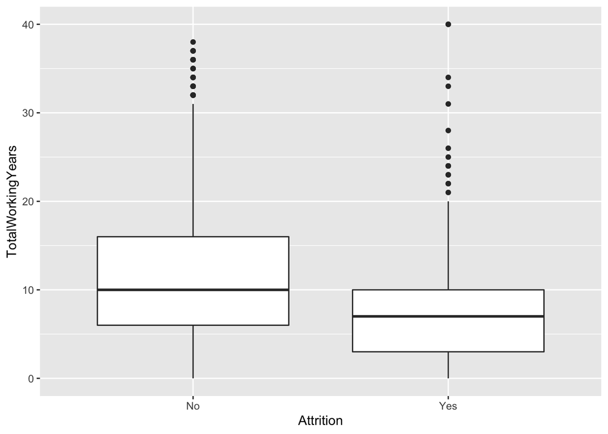

```r
ggplot(attrition, aes(Attrition, TotalWorkingYears)) +
  geom_boxplot()
```

Test for difference in means

```r
t.test(TotalWorkingYears ~ Attrition, data = attrition)
```

```
##
##  Welch Two Sample t-test
##
## data:  TotalWorkingYears by Attrition
## t = 7.0192, df = 350.88, p-value = 1.16e-11
## alternative hypothesis: true difference in means is not equal to 0
## 95 percent confidence interval:
##  2.604401 4.632019
## sample estimates:
##  mean in group No mean in group Yes
##         11.862936          8.244726
```

Check class balance:

```r
attrition %>% count(Attrition)
```

```
##   Attrition    n
## 1        No 1233
## 2       Yes  237
```

```r
table(attrition$Attrition) # base R
```

```
##
##   No  Yes
## 1233  237
```

Create a balanced dataset with the same number of observations in both classes

```r
attr_No <- attrition %>%
  filter(Attrition == "No") %>%
  sample_n(size = 237)

attr_Yes <- attrition %>%
  filter(Attrition == "Yes")

attr <- rbind(attr_No, attr_Yes)

# or

attr <- attrition %>%
  group_by(Attrition) %>%
  slice_sample(n = 237)

# transform outcome to numeric 0-1
nattr <- attr %>%
  mutate(Y = as.numeric(Attrition) - 1) %>%
  select(Y, TotalWorkingYears)
```

## Classification: linear regression?

Plot linear regression line, change the threshold

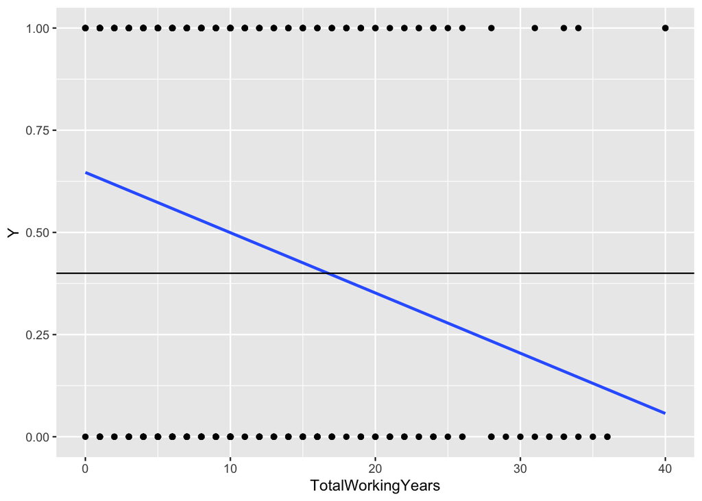

```r
ggplot(nattr, aes(x = TotalWorkingYears, y = Y)) +
  geom_point() +
  geom_smooth(method = "lm", se = FALSE) +
  geom_hline(yintercept = .4) # or e.g. mean(nattr$Y)
```

Problems:

- Can predict outside 0-1 range
- Not directly interpretable as probabilities

### Thresholding ideas

Choose a threshold/cutoff value for predictor $X$, say $c$, and then classify

- $\hat Y = 1$ if $X \geq c$
- $\hat Y = 0$ otherwise

Or if the association is negative, change the sign

As we vary $c$, we trade-off between kinds of errors: false positives and false negatives

In the simple case with thresholding one predictor, the classification/decision rules are all equivalent whether we use linear regression or logistic regression (as long as the fitted relationship is monotone)

For **multiple** regression–when we have more predictors–we can then transform a numeric prediction from the model $\hat Y$ to a classification by using a threshold rule on the scale of the predictions (instead of on the scale of one predictor as before)

- $\hat Y = 1$ if $x^T \hat \beta \geq c$
- $\hat Y = 0$ otherwise

## Logistic regression

```r
model_glm <- glm(Y ~ TotalWorkingYears, data = nattr, family = "binomial")
summary(model_glm)
```

```
##
## Call:
## glm(formula = Y ~ TotalWorkingYears, family = "binomial", data = nattr)
##
## Deviance Residuals:
##     Min       1Q   Median       3Q      Max
## -1.4534  -1.1713   0.1708   1.1025   2.0385
##
## Coefficients:
##                   Estimate Std. Error z value Pr(>|z|)
## (Intercept)        0.62893    0.16041   3.921 8.83e-05 ***
## TotalWorkingYears -0.06432    0.01369  -4.697 2.64e-06 ***
## ---
## Signif. codes:  0 '***' 0.001 '**' 0.01 '*' 0.05 '.' 0.1 ' ' 1
##
## (Dispersion parameter for binomial family taken to be 1)
##
##     Null deviance: 657.10  on 473  degrees of freedom
## Residual deviance: 632.16  on 472  degrees of freedom
## AIC: 636.16
##
## Number of Fisher Scoring iterations: 4
```

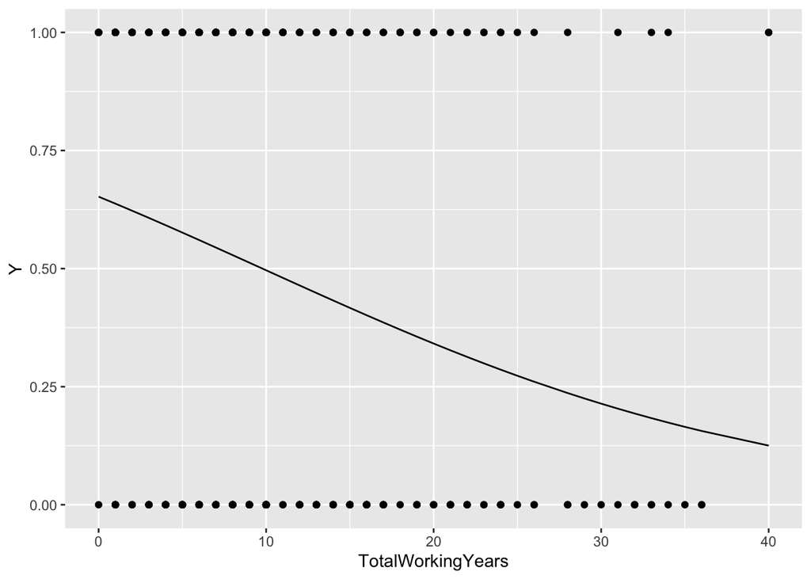

```r
augment(model_glm, type.predict = "response") %>%
  ggplot(aes(TotalWorkingYears, Y)) +
  geom_point() +
  geom_line(aes(y = .fitted))
```

### Modeling assumption

$$\text{logit}[P(Y = 1|X)] = \beta_0 + \beta_1 X$$

$$P(Y = 1|X) = \frac{e^{\beta_0 + \beta_1 X}}{1 + e^{\beta_0 + \beta_1 X}}$$

### Interpreting coefficients

```r
exp(coef(model_glm))
```

```
##       (Intercept) TotalWorkingYears
##         1.8756090         0.9377032
```

### Inference

```r
exp(confint(model_glm))
```

```
##                       2.5 %   97.5 %
## (Intercept)       1.3745869 2.580038
## TotalWorkingYears 0.9120732 0.962495
```

Model evaluation measures

```r
glance(model_glm)
```

```
## # A tibble: 1 x 8
##   null.deviance df.null logLik   AIC   BIC deviance df.residual  nobs
##           <dbl>   <int>  <dbl> <dbl> <dbl>    <dbl>       <int> <int>
## 1          657.     473  -316.  636.  644.     632.         472   474
```

Diagnostic plots: can do this but less common, harder to interpret “deviance residuals”

(Warning: residual plots almost always show “patterns”, can’t be interpreted the same way as for linear regression)

## Balance and (re)calibration

What portion of data are classified using a given cutoff for the predicted probability?

```r
mean(predict(model_glm, type = "response") > 0.5)
```

```
## [1] 0.5611814
```

Try different cutoffs

```r
c(.3, .4, .5, .6, 7) %>%
  map_dbl(function(cutoff) mean(predict(model_glm, type = "response") > cutoff))
```

```
## [1] 0.9219409 0.8417722 0.5611814 0.1687764 0.0000000
```

Tabulate a confusion matrix using dplyr functions

```r
conf_mat <- function(fitted_glm, cutoff = .5) {
  augment(fitted_glm, type.predict = "response") %>%
    mutate(Yhat = as.numeric(.fitted > cutoff)) %>%
    count(Y, Yhat)
}
```

```r
conf_mat(model_glm)
```

```
## # A tibble: 4 x 3
##       Y  Yhat     n
##   <dbl> <dbl> <int>
## 1     0     0   128
## 2     0     1   109
## 3     1     0    80
## 4     1     1   157
```

Try another cutoff

```r
conf_mat(model_glm, .6)
```

```
## # A tibble: 4 x 3
##       Y  Yhat     n
##   <dbl> <dbl> <int>
## 1     0     0   220
## 2     0     1    17
## 3     1     0   174
## 4     1     1    63
```

## Multiple regression model

(Complete outside of class time unless time permits)

Pick a few predictors and repeat the above

```r
library(GGally)
```

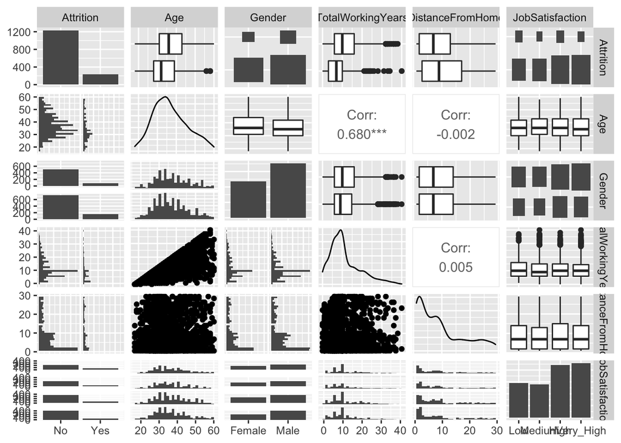

```r
options(warnings= -1)
attrition %>%
  select(Attrition, Age, Gender, TotalWorkingYears,
         DistanceFromHome, JobSatisfaction) %>%
  ggpairs(progress = FALSE, lower = list(bins = 20))
```

### Modeling assumption

$$\text{logit}[ P(Y = 1|X)] = X \beta$$
(Matrix multiplication, has an intercept if $X$ has a constant column)

## Simulation

Write a function like `y = f(x) + noise` to generate data (with sample size as an input to the function)

Start with a linear function and Gaussian noise

```r
f <- function(x) 1 - 2*x
my_dgp <- function(n) {
  x <- runif(n)
  noise <- rnorm(n)
  y <- f(x) + noise
  return(data.frame(x = x, y = y))
}
```

Simulate one dataset with a sample size of 20, fit a linear regression model, and extract the slope estimate

```r
coef(lm(y ~ x, data = my_dgp(n = 20)))[2]
```

```
##         x
## -2.587743
```

Repeat this 100 times using `replicate()`, plot a histogram of the coefficient estimates, add a `geom_vline` at the true coefficient value. Increase the sample size and try again

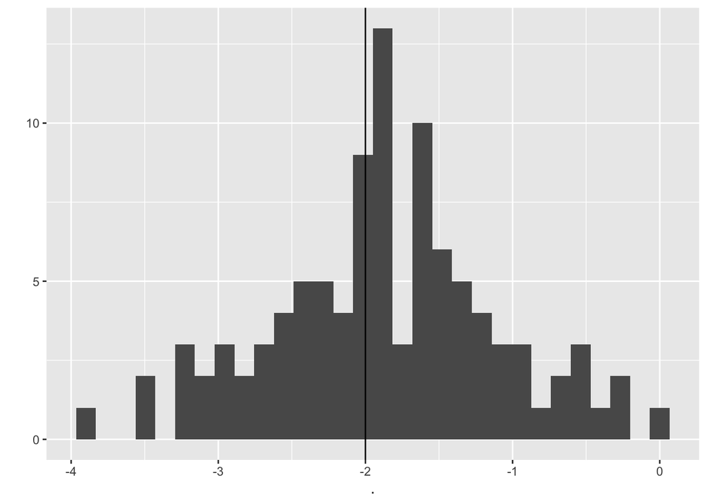

```r
replicate(100, coef(lm(y ~ x, data = my_dgp(n = 20)))[2]) %>%
  qplot() + geom_vline(xintercept = -2)
```

### Complexify the above

(Complete outside of class time unless time permits)

Now try making `f` a function of two variables, where `x1` and `x2` are both (possibly noisey) functions of a hidden variable `u`

What are the true coefficients? How do we interpret them? What happens if we regress on only `x1` or only `x2`? What would be the change in outcome if we could intervene on `x1` (erasing the influence of `u` on `x1` but keeping it for `x2`)? What if we could intervene on `u`?

```r
beta1 <- -1
beta2 <- -2
f <- function(x1, x2) 1 + beta1 * x1 + beta2 * x2
my_dgp <- function(n) {
  u <- rnorm(n)
  x1 <- 3*u + rnorm(n)
  x2 <- 15 - 7*u + rnorm(n)
  y <- f(x1, x2) + rnorm(n)
  return(data.frame(x1 = x1, x2 = x2, y = y))
}
```

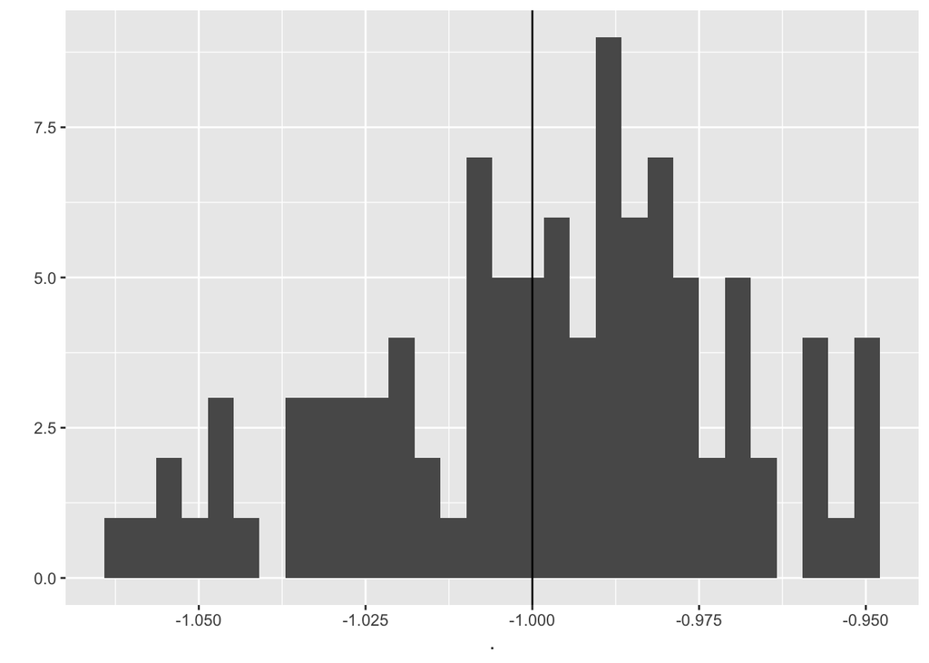

```r
replicate(100, coef(lm(y ~ x1 + x2, data = my_dgp(n = 1000)))[2]) %>%
  qplot() + geom_vline(xintercept = beta1)
```

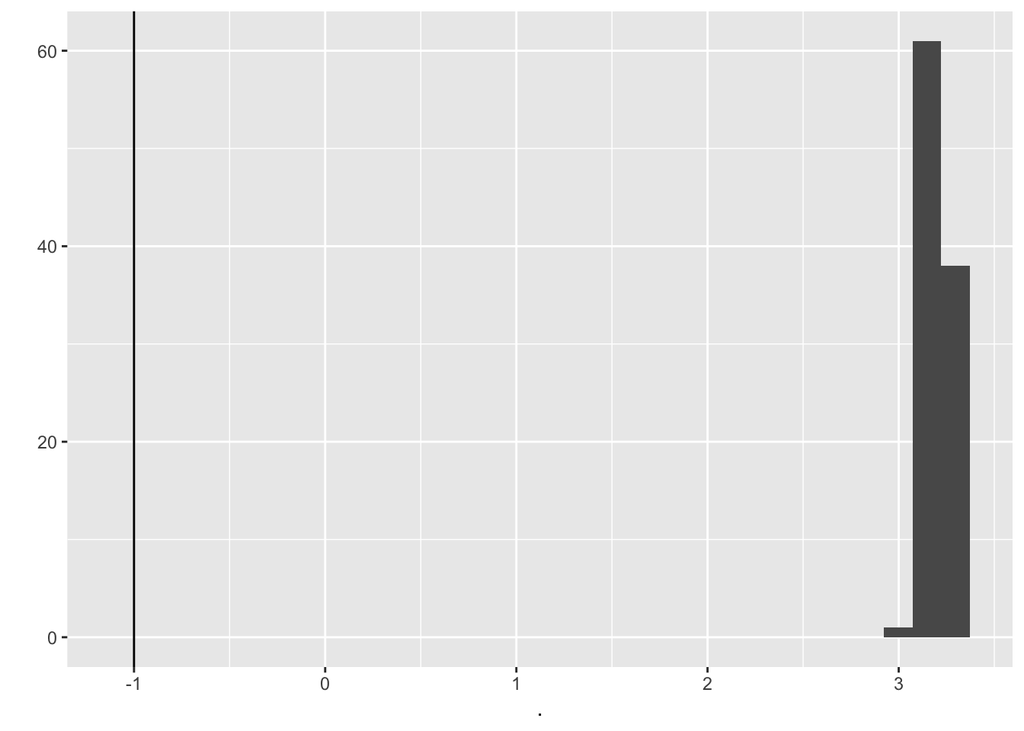

```r
replicate(100, coef(lm(y ~ x1, data = my_dgp(n = 1000)))[2]) %>%
  qplot() + geom_vline(xintercept = beta1)
```

If we regress on only one at a time the estimates can be biased (omitted variable bias)

If we could intervene on `x1` directly then `beta1` (the true value, not the estimate) would tell us the causal effect on the outcome

If we could intervene on `u` then the total effect on `y` would involve both `beta1` and `beta2`, as well as the coefficients of `u` on both `x1` and `x2`

e.g. increasing `u` by 1 would make `x1` increase by 3 and `x2` decrease by 7, hence `y` would change by `3*beta - 7*beta2`

### Extra practice

(Complete outside of class time unless time permits)

Repeat the previous simulations but generate a binary outcome and use logistic regression to estimate coefficients

```r
# y <- rbinom(n, 1, exp(f(x))/(1+exp(f(x))))
```